# **Customer Analytics Capstone Project**

- **Darshil Desai**

#### *NOTE*: Dear Viewer, please click on the button below if you wish to see the code. Personally, I would recommend the following:

- 1. First, view the report **without** the code so as to quickly be able to read up and understand the analysis
- 1. Following which feel free to view the report **with** the code that to see how the analysis was facilitated

```python
from IPython.display import HTML

HTML('''<script>
code_show=false;
function code_toggle() {
 if (code_show){
 $('div.input').hide();
 } else {
 $('div.input').show();
 }
 code_show = !code_show
}
$( document ).ready(code_toggle);
</script>
<form action="javascript:code_toggle()"><input type="submit" value="Click here to toggle on/off the raw code."></form>''')
```

```python
# Importing all neccessary Python modules
import pandas as pd
import numpy as np
import matplotlib.pyplot as plt
import seaborn as sns
from itertools import combinations

import statsmodels.api as sm
from statsmodels.formula.api import ols

from scipy.stats import chi2_contingency
from scipy.stats import chi2
pd.set_option('display.max_columns', None)

from sklearn.linear_model import LinearRegression, LogisticRegressionCV,LogisticRegression
from sklearn.model_selection import train_test_split
from sklearn.metrics import confusion_matrix
import itertools

import warnings
warnings.filterwarnings('ignore')
```

```python
# Importing Customer Churn
customer_churn_df = pd.read_csv('Customer_Churn_Dataset.csv')

# Importing Customer Lifetime Value
customer_lifetime_value = pd.read_csv('Marketing_Customer_Value_Analysis.csv')

# Importing Marketing Campaign Data
marketing_camp_df = pd.read_csv('Marketing_Campaign_Effectiveness.csv')
```

# Overview

In this report, I will focus on analyzing datasets pertaining to two key metrics observed in the customer analytics domain, namely: **Customer Lifetime Value** & **Dollar Value of Sales Attributed from Marketing Campaign**. Before we dive deeper into the report, I would like to highlight what each of the metrics really entail:

### Customer Lifetime Value :

One of the most vital metrics observed at growing companies, Customer Lifetime Value or CLTV, refers to the total monetary value to be gained from a customer throughout the customer's journey in the company's ecosystem.

The premise behind this metric is to be able to predetermine, using historical data, how much a customer is actually worth to the company, therefore allowing a company to perhaps reallocate their resources to pursue newer customers with similar profiles to existing customers with high CLTV values. The CLTV metric is dynamic which means that the value changes over time. Customer with a longer customer history are bound to have a higher CLTV.

```python
print('Customer Analytics Dataset looks like this:')
print('----------------------------')
customer_lifetime_value.head(2)
```

```
Customer Analytics Dataset looks like this:
----------------------------
```

|  | Customer | State | Customer Lifetime Value | Response | Coverage | Education | Effective To Date | EmploymentStatus | Gender | Income | Location Code | Marital Status | Monthly Premium Auto | Months Since Last Claim | Months Since Policy Inception | Number of Open Complaints | Number of Policies | Policy Type | Policy | Renew Offer Type | Sales Channel | Total Claim Amount | Vehicle Class | Vehicle Size |
| --- | --- | --- | --- | --- | --- | --- | --- | --- | --- | --- | --- | --- | --- | --- | --- | --- | --- | --- | --- | --- | --- | --- | --- | --- |
| 0 | BU79786 | Washington | 2763.519279 | No | Basic | Bachelor | 2/24/11 | Employed | F | 56274 | Suburban | Married | 69 | 32 | 5 | 0 | 1 | Corporate Auto | Corporate L3 | Offer1 | Agent | 384.811147 | Two-Door Car | Medsize |
| 1 | QZ44356 | Arizona | 6979.535903 | No | Extended | Bachelor | 1/31/11 | Unemployed | F | 0 | Suburban | Single | 94 | 13 | 42 | 0 | 8 | Personal Auto | Personal L3 | Offer3 | Agent | 1131.464935 | Four-Door Car | Medsize |

```python
print('The variables in the Customer Lifetime Value Dataset are as follows: ')
print('----------------------------')
for x in customer_lifetime_value.columns:
    print(x)
```

```
The variables in the Customer Lifetime Value Dataset are as follows:
----------------------------
Customer
State
Customer Lifetime Value
Response
Coverage
Education
Effective To Date
EmploymentStatus
Gender
Income
Location Code
Marital Status
Monthly Premium Auto
Months Since Last Claim
Months Since Policy Inception
Number of Open Complaints
Number of Policies
Policy Type
Policy
Renew Offer Type
Sales Channel
Total Claim Amount
Vehicle Class
Vehicle Size
```

Although many variables in this dataset are self-explanatory, some require more explainations:

- Customer: The customer ID of an individual customer
- State, Gender, Income, Education, Employment Status, Location Code, Marital Status: Demographic and meta-data about a customer's background
- Coverage: The type of insurance coverage this individual has signed up for
- Effective to Date: Expiry date of the insurance policy
- Monthly Premium Auto: The amount paid to the insurance company on a regular basis, every month in this case, in exchange for insurance coverage
- Months Since Last Claim: Number of months since customer filed an insurance claim
- Months Since Policy Inception - Number of months since customer opened the insurance policy account
- Number of Open Complaints: Number of complaints filed by the customer
- Number of Policies: Number of insurance policies held by the customer
- Policy Type, Policy, Response: Data about the insurance policy
- Renew Offer Type: Which offer sent to the customer for renewal
- Sales Channel: What sales channel did this customer come from
- Total Claim Amount: The total amount of claim
- Vehicle Class, Vehicle Size: Vehicle information provided where an auto-insurance is present.

### Dollar Value of Sales Attributed from Marketing Campaigns :

Marketing campaigns promote products or services through different types of media, such as television, print, and online platforms such as social media ([Source](https://www.investopedia.com/terms/m/marketing-campaign.asp)). Marketing campaigns are repurposed for specific goals. For instance: some marketing campaigns focus on improving brand image while others focus on a more tangible return such as prompting target audience to sign up on a website or purchase a product.

The dataset used in this report focuses on marketing campaign data and its consequential effect on sales of a company. The premise behind analyzing this dataset is to determine which marketing campaigns prove to be most lucrative given certain parameters and also develop a predictive model to hopefully allow us to predict how well a marketing campaign might do prior to its release.

```python
print('Marketing Campaign Dataset looks like this: ')
print('----------------------------')
marketing_camp_df.head(2)
```

```
Marketing Campaign Dataset looks like this:
----------------------------
```

|  | MarketID | MarketSize | LocationID | AgeOfStore | Promotion | week | SalesInThousands |
| --- | --- | --- | --- | --- | --- | --- | --- |
| 0 | 1 | Medium | 1 | 4 | 3 | 1 | 33.73 |
| 1 | 1 | Medium | 1 | 4 | 3 | 2 | 35.67 |

```python
print('The variables in the Marketing Campaign Dataset are as follows: ')
print('----------------------------')
for x in marketing_camp_df.columns:
    print(x)
```

```
The variables in the Marketing Campaign Dataset are as follows:
----------------------------
MarketID
MarketSize
LocationID
AgeOfStore
Promotion
week
SalesInThousands
```

## Case 1: **Customer Lifetime Value Data**

I will now begin analyzing each each dataset as a separate case. Within each case, I will conduct my analysis as follows:

- **A)** Exploratory Data Analysis
- **B)** Forming a Hypothesis
- **D)** Statistical Feature Selection
- **D)** Feature Engineering
- **E)** Training and Testing a Predictive Model
- **F)** Interpreting the Predictive Model

### A) Exploratory Data Analysis

The first step to any form of analysis, I believe, is exploring the data and examining its structure and its distributions. Here I will explore the data on two fronts:

- First, I will only look at the categorical data and examine their proportions within the dataset. For your reference, categorical data contains a finite number of distinct groups. Example: type of fruits
- Second, I will move on to exploring interesting relationships between the continuous and categorical variables.

#### Exploring Categorical Data

The visual analysis below yields the following interesting observations:

- **Figure 1**: Majority of the customers in this dataset hail from western United States. Interestingly, this may beg the question whether or not any statistical estimates derived from this dataset can truly be indicative of the overall population in the United States. Most likely not but yet this is the data we have to work with.
- **Figure 2**: Most of the customers in the dataset do not pursue education after under-graduation. This observance, however, is not a surprising as it mimics the U.S census data pertaining to education levels wherein a much smaller percentage of individuals enroll in master or doctorate programs.

  On the other hand, because we are not given the age of the customers, we can also assume that most customers in this dataset are perhaps still in high school or pursuing their undergraduate degree.
- **Figure 3**: We can, however, be assured that any statistical analysis derived from this dataset is not gender biased as it the proportion of male vs female customers is roughly equal.
- **Figure 4**: Here we see that most auto claims yield from customers with a four door car or more commonly Sedans. This observation is an unsurprising one as it mimics the general car ownership trend in the US wherein most people own Sedans.

```
''
```

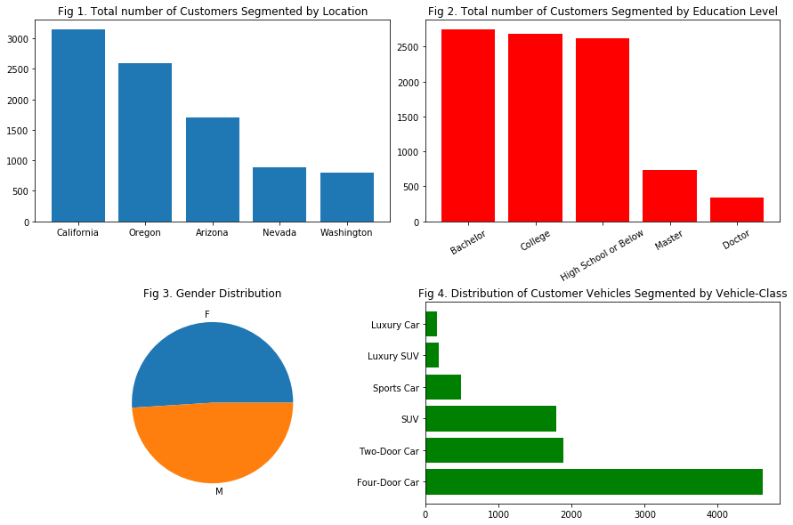

```python
# CLTV

plt.figure(figsize=(15,10))
plt.subplots_adjust(left=None, bottom=None, right=None, top=None, wspace=0.1, hspace=0.4)

#-------------------------------------------
plt.subplot(2,2,1)
state_breakdown = customer_lifetime_value.State.value_counts()
plt.bar(state_breakdown.index, state_breakdown)
plt.title('Fig 1. Total number of Customers Segmented by Location')

# #-------------------------------------------
plt.subplot(2,2,2)

edu_breakdown = customer_lifetime_value.Education.value_counts()
plt.bar(edu_breakdown.index, edu_breakdown, color='r')
plt.xticks(rotation=30)
plt.title('Fig 2. Total number of Customers Segmented by Education Level')

# #-------------------------------------------
plt.subplot(2,2,3)
gender_breakdown= customer_lifetime_value.Gender.value_counts()
plt.pie(gender_breakdown, labels=gender_breakdown.index)
plt.title('Fig 3. Gender Distribution')


# #-------------------------------------------
plt.subplot(2,2,4)
vehicle_breakdown= customer_lifetime_value['Vehicle Class'].value_counts()
plt.barh(vehicle_breakdown.index, vehicle_breakdown ,color = 'g')
plt.title('Fig 4. Distribution of Customer Vehicles Segmented by Vehicle-Class')
;
```

### Exploring Interesting Relationships Within the Dataset

In this section I will explore how a combination of different variables within the dataset yield interesting insights. I employ the use of aggregations and group bys to achieve this outcome.

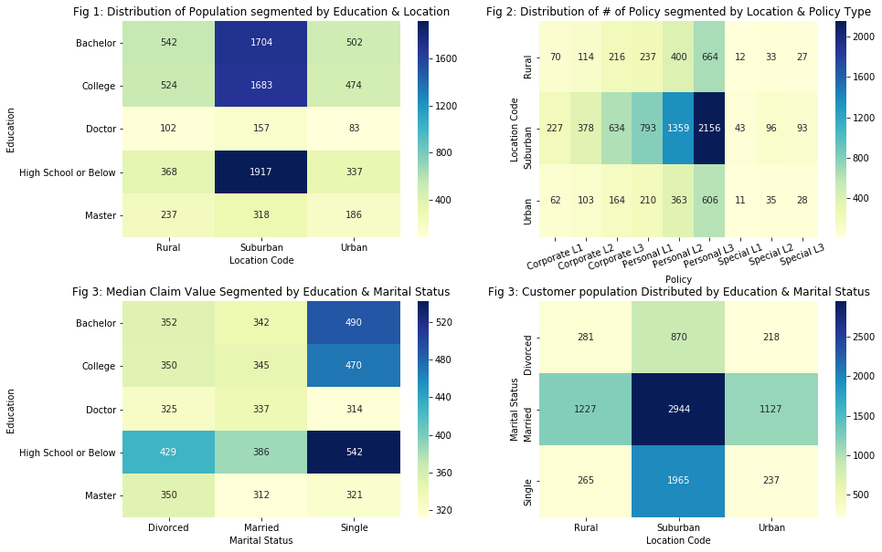

```python
#-------------------------------------------
plt.figure(figsize=(15,10))
plt.subplots_adjust(left=None, bottom=None, right=None, top=None, wspace=0.2, hspace=0.3)

plt.subplot(2,2,1)
sns.heatmap(pd.crosstab(customer_lifetime_value.Education, customer_lifetime_value['Location Code']),
            annot=True,fmt='1.0f', cmap="YlGnBu")
plt.title('Fig 1: Distribution of Population segmented by Education & Location')

# #-------------------------------------------
plt.subplot(2,2,2)
sns.heatmap(customer_lifetime_value.groupby(['Location Code', 'Policy'])['Policy'].count().unstack()
           , annot=True,fmt='1.0f', cmap="YlGnBu")
plt.xticks(rotation=20)
plt.title('Fig 2: Distribution of # of Policy segmented by Location & Policy Type')

# #-------------------------------------------
plt.subplot(2,2,3)
sns.heatmap(customer_lifetime_value.groupby(['Education', 'Marital Status'])['Total Claim Amount'].median().unstack()
           , cmap="YlGnBu", annot=True,fmt='1.0f')
plt.title('Fig 3: Median Claim Value Segmented by Education & Marital Status')

# #-------------------------------------------
plt.subplot(2,2,4)
sns.heatmap(pd.crosstab(customer_lifetime_value['Marital Status'], customer_lifetime_value['Location Code'])
           , annot=True,fmt='1.0f', cmap="YlGnBu")
plt.title('Fig 3: Customer population Distributed by Education & Marital Status');
```

### B) Forming a Hypothesis

After observing the dataset at hand, I would like to go ahead and pursue my analysis in the direction of predicting the **Customer Lifetime Value** metric. As mentioned earlier, this metric is a vital number that represents the estimated dollar value to be gained from a customer. Therefore, I believe that a successful predictive model that can determine the Customer Lifetime Value, of not only existing customers but also future customers, can prove to be very profitable in the long run.

My hypothesis here will be as follows: **A certain combination of variables in this dataset will allow me to develop a predictive model that will predict the Customer Lifetime Value with a reasonable amount of error**

### C) Feature Selection Using Statistical Techniques

In order to find the "combination of variables" that will allow me to predict the Customer Lifetime Value metric, I will need to determine which variables or features will contribute the most to the prediction variable (CLTV). This process of manually or automatically selecting features based on some logic is known as feature selection. It is vital that feature selection is conducted as *having irrelevant features in your data can decrease the accuracy of the models and make your model learn based on irrelevant*, [Source_](https://towardsdatascience.com/feature-selection-techniques-in-machine-learning-with-python-f24e7da3f36e)

In our dataset, we possess a combination of several categorical variables and continuous variables alike. In order to determine the "relevant" features, we can perform a variety of statistical tests that can test the independence of one variable when compared to another. The Statistical test to use depends on the type of data present in each of the two samples ( or variables in our case) to compare.

Some of the statistical tests I will use in this case are as follows:

- **ANOVA Tests**: ANOVA or Analysis of Variance refers to the statistical technique most commonly utilized to determine whether the means of two or more groups are significantly different from one another. The comparison of two samples is usually done using One-Way ANOVA wherein we wish to compare the groups to find out if there is any significant difference between them.

  In the context of machine learning, one-way ANOVA tests are used to determine the type of relationship between a categorical variable and a continuous variable. The goal here is two-fold, we would ideally want there to be no significant relationship between a categorical variable and a continuous variable within a feature set. This is because we would then be simply using similar two or more similar variable in our models which reduces the model’s effectiveness as generalizing well. On the other hand, we would want there to be a significant relationship present between a categorical variable and a continuous variable if one of the variables was a dependent variable. Answer Expanded on from my Assignment 3 submission
- **Correlation Coefficient**: The most commonly used metric to test the level of independence between two continuous variables is the correlation coefficient or the R^2 metric. Ranging from -1 to +1, two variables are can be positively or negatively correlated at varying levels of strength. In the context of this analysis, we will:
  - Test correlation amongst our feature set or independent variables
  - Test correlation between each independent variable and the dependent variable.

```python
"""
HELPER FUNCTIONS
: Here I will define some helper functions which will allow me to perform statistical tests using minimal code.
"""

def chi_sq_test(row,data, a=0.05):
    """
    Performs Chi-Square test between two categorical variables

    Returns
    ---
    : p-value from chi-square test
    """
    # Perform Chi-Square test here
    stat, p, dof, expected = chi2_contingency(pd.crosstab(data[row['column_1']], data[row['column_2']] ))

    # Compares P value to alpha.
    return p


def one_way_ANOVA(row):
    """
    Perform one way ANOVA test between continous and categorical variable to determine association
    """
    mod = ols('{} ~ {}'.format(row['column_1'], row['column_2']),data=a).fit()
    aov_table = sm.stats.anova_lm(mod, typ=2)

    # P-value
    return aov_table['PR(>F)'].loc['{}'.format(row['column_2'])]


def pearson_coeff(row):
    """
    Performs Pearson's Correlation Coefficient test


    """
```

#### ANOVA Tests__: Independence between Categorical Independent Variables and the Continuous Dependent Variable

As mentioned above, we would want there to be a significant relationship present between a categorical variable and a continuous variable if one of the variables was a dependent variable(what we are trying to predict) and the other an independent variable (what we are using to predict). In this case we check whether there exists equal variance between the categorical and the continuous variable, if there exists no significant difference then one cannot be used to predict the other.

```python
# Selecting ONLY Categorical columns along with the target variables
categorical_columns_cltv_anova = [x for x in customer_lifetime_value.columns if x not in ['Customer', 'Effective To Date', 'Income', 'Monthly Premium Auto', 'Months Since Last Claim' \
                                             , 'Months Since Policy Inception', 'Number of Open Complaints','Number of Policies', 'Total Claim Amount'] ]

# Duplicate column names
a = customer_lifetime_value[categorical_columns_cltv_anova]

# Reformat
cltv_column_names =  ['_'.join(y.split()) for y in categorical_columns_cltv_anova if len(y.split())]

# Reassign column names
a.columns = cltv_column_names

# All combinations to test out for ANOVA association tests
print('Here we will test the following pairs of Independent Categorical Variable vs Customer_Lifetime_Value')
print('----------------------------')
cltv_anova_combination_df = pd.DataFrame([('Customer_Lifetime_Value', y) for y in a.columns if y != 'Customer_Lifetime_Value'], columns=['column_1', 'column_2'])
cltv_anova_combination_df
```

```
Here we will test the following pairs of Independent Categorical Variable vs Customer_Lifetime_Value
----------------------------
```

|  | column_1 | column_2 |
| --- | --- | --- |
| 0 | Customer_Lifetime_Value | State |
| 1 | Customer_Lifetime_Value | Response |
| 2 | Customer_Lifetime_Value | Coverage |
| 3 | Customer_Lifetime_Value | Education |
| 4 | Customer_Lifetime_Value | EmploymentStatus |
| 5 | Customer_Lifetime_Value | Gender |
| 6 | Customer_Lifetime_Value | Location_Code |
| 7 | Customer_Lifetime_Value | Marital_Status |
| 8 | Customer_Lifetime_Value | Policy_Type |
| 9 | Customer_Lifetime_Value | Policy |
| 10 | Customer_Lifetime_Value | Renew_Offer_Type |
| 11 | Customer_Lifetime_Value | Sales_Channel |
| 12 | Customer_Lifetime_Value | Vehicle_Class |
| 13 | Customer_Lifetime_Value | Vehicle_Size |

```python
print('Perforing the ANOVA tests on all the pairs shown above')
print('----------------------------')
cltv_anova_combination_df['p_value_ANOVA']= cltv_anova_combination_df.apply(one_way_ANOVA,1)
```

```
Perforing the ANOVA tests on all the pairs shown above
----------------------------
```

```python
print('All combinations where p-value is less than alpha and therefore we reject the null hypothesis')
print('----------------------------')
cltv_anova_combination_df[cltv_anova_combination_df.p_value_ANOVA <= 0.05]
```

```
All combinations where p-value is less than alpha and therefore we reject the null hypothesis
----------------------------
```

|  | column_1 | column_2 | p_value_ANOVA |
| --- | --- | --- | --- |
| 2 | Customer_Lifetime_Value | Coverage | 6.015897e-58 |
| 3 | Customer_Lifetime_Value | Education | 4.603615e-02 |
| 4 | Customer_Lifetime_Value | EmploymentStatus | 4.250587e-03 |
| 7 | Customer_Lifetime_Value | Marital_Status | 3.628104e-02 |
| 10 | Customer_Lifetime_Value | Renew_Offer_Type | 1.238400e-16 |
| 12 | Customer_Lifetime_Value | Vehicle_Class | 2.085526e-267 |

```python
print('All combinations where p-value is greater than than the alpha and therefore we DO NOT reject the null hypothesis')
print('----------------------------')
cltv_anova_combination_df[cltv_anova_combination_df.p_value_ANOVA > 0.05]
```

```
All combinations where p-value is greater than than the alpha and therefore we DO NOT reject the null hypothesis
----------------------------
```

|  | column_1 | column_2 | p_value_ANOVA |
| --- | --- | --- | --- |
| 0 | Customer_Lifetime_Value | State | 0.895599 |
| 1 | Customer_Lifetime_Value | Response | 0.393483 |
| 5 | Customer_Lifetime_Value | Gender | 0.193399 |
| 6 | Customer_Lifetime_Value | Location_Code | 0.897627 |
| 8 | Customer_Lifetime_Value | Policy_Type | 0.112689 |
| 9 | Customer_Lifetime_Value | Policy | 0.304195 |
| 11 | Customer_Lifetime_Value | Sales_Channel | 0.450278 |
| 13 | Customer_Lifetime_Value | Vehicle_Size | 0.092377 |

#### Correlation Testing between continuous independent & target variables

```
Testing all correlations among the continuous independent variable
----------------------------
```

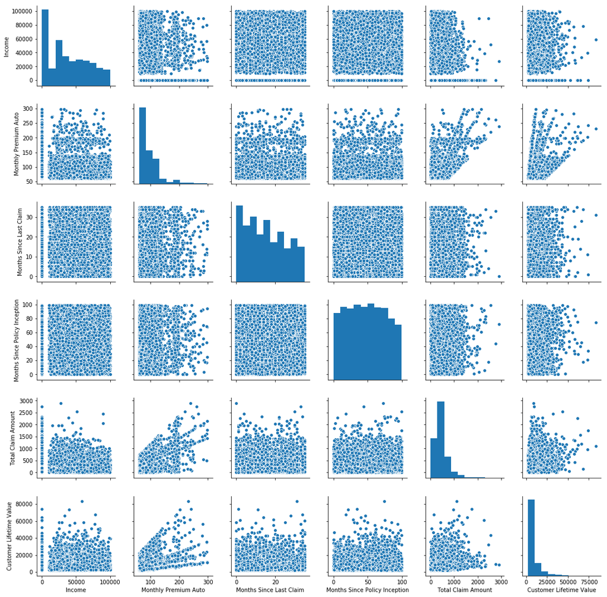

```python
print('Testing all correlations among the continuous independent variable')
print('----------------------------')
sns.pairplot(customer_lifetime_value[['Income', 'Monthly Premium Auto',
                                      'Months Since Last Claim' , 'Months Since Policy Inception',
                                       'Total Claim Amount', 'Customer Lifetime Value']]);
```

```python
corr_df_cltv = pd.DataFrame([(x, np.corrcoef(customer_lifetime_value[x[0]].astype(float),
                                             customer_lifetime_value[x[1]].astype(float))[0][1]) for x in combinations(customer_lifetime_value[[ 'Income', 'Monthly Premium Auto', 'Months Since Last Claim' , 'Months Since Policy Inception', 'Number of Open Complaints','Number of Policies', 'Total Claim Amount']].columns,2)]
            , columns = ['variables_to_compare', 'correlation_coeffs'])
```

```python
print('First 10 R-Squared Results for all combinations of continuous features')
print('----------------------------')
corr_df_cltv.head(10)
```

```
First 10 R-Squared Results for all combinations of continuous features
----------------------------
```

|  | variables_to_compare | correlation_coeffs |
| --- | --- | --- |
| 0 | (Income, Monthly Premium Auto) | -0.016665 |
| 1 | (Income, Months Since Last Claim) | -0.026715 |
| 2 | (Income, Months Since Policy Inception) | -0.000875 |
| 3 | (Income, Number of Open Complaints) | 0.006408 |
| 4 | (Income, Number of Policies) | -0.008656 |
| 5 | (Income, Total Claim Amount) | -0.355254 |
| 6 | (Monthly Premium Auto, Months Since Last Claim) | 0.005026 |
| 7 | (Monthly Premium Auto, Months Since Policy Inc... | 0.020257 |
| 8 | (Monthly Premium Auto, Number of Open Complaints) | -0.013122 |
| 9 | (Monthly Premium Auto, Number of Policies) | -0.011233 |

Based on the feature selection techniques above, I believe the following variables can be used to predict the **Customer Lifetime Value**:

**Categorical Variables**

- Coverage
- Education
- EmploymentStatus
- Marital_Status
- Renew_Offer_Type
- Vehicle_Clas

**Continuous Variables**

- Income
- Monthly Premium Auto
- Months Since Last Claim
- Number of Open Complaints
- Number of Policies

### D) Feature Engineering

We have with us the dataset in tidy format. However, there lies a need to transform many of the relevant variables into the appropriate format in order to be able to feed it to machine learning models and make sense of it. I will make use of the following features that I deem relevant to predict customer lifetime value:

#### Converting Categorical Variables into their respective one-hot encoded versions

```python
customer_lifetime_value_categorical_dummies =  pd.get_dummies(customer_lifetime_value[['Coverage', 'Education','EmploymentStatus','Marital Status'
                        , 'Renew Offer Type', 'Vehicle Class']], drop_first=True)
```

#### Standardizing Numerical Variables to bring them to the same scale

```python
customer_lifetime_value_cont_variables = customer_lifetime_value[['Income', 'Monthly Premium Auto', 'Months Since Last Claim'
                                                                 , 'Number of Open Complaints', 'Number of Policies']]
```

```python
customer_lifetime_value_cont_variables_standardized =  (customer_lifetime_value_cont_variables - customer_lifetime_value_cont_variables.mean())/customer_lifetime_value_cont_variables.std()
```

#### Combining Categorical and Continuous Features to Create the Entire Feature Set

```python
finalized_features_cltv = pd.concat([customer_lifetime_value_cont_variables_standardized,
                                    customer_lifetime_value_categorical_dummies],1)
```

```python
print('Finalized Features to fit into a model')
print('----------------------------')
finalized_features_cltv.head()
```

```
Finalized Features to fit into a model
----------------------------
```

|  | Income | Monthly Premium Auto | Months Since Last Claim | Number of Open Complaints | Number of Policies | Coverage_Extended | Coverage_Premium | Education_College | Education_Doctor | Education_High School or Below | Education_Master | EmploymentStatus_Employed | EmploymentStatus_Medical Leave | EmploymentStatus_Retired | EmploymentStatus_Unemployed | Marital Status_Married | Marital Status_Single | Renew Offer Type_Offer2 | Renew Offer Type_Offer3 | Renew Offer Type_Offer4 | Vehicle Class_Luxury Car | Vehicle Class_Luxury SUV | Vehicle Class_SUV | Vehicle Class_Sports Car | Vehicle Class_Two-Door Car |
| --- | --- | --- | --- | --- | --- | --- | --- | --- | --- | --- | --- | --- | --- | --- | --- | --- | --- | --- | --- | --- | --- | --- | --- | --- | --- |
| 0 | 0.612794 | -0.703886 | 1.678007 | -0.422226 | -0.822603 | 0 | 0 | 0 | 0 | 0 | 0 | 1 | 0 | 0 | 0 | 1 | 0 | 0 | 0 | 0 | 0 | 0 | 0 | 0 | 1 |
| 1 | -1.239549 | 0.022690 | -0.208175 | -0.422226 | 2.106045 | 1 | 0 | 0 | 0 | 0 | 0 | 0 | 0 | 0 | 1 | 0 | 1 | 0 | 1 | 0 | 0 | 0 | 0 | 0 | 0 |
| 2 | 0.365690 | 0.429572 | 0.288189 | -0.422226 | -0.404225 | 0 | 1 | 0 | 0 | 0 | 0 | 1 | 0 | 0 | 0 | 1 | 0 | 0 | 0 | 0 | 0 | 0 | 0 | 0 | 1 |
| 3 | -1.239549 | 0.371446 | 0.288189 | -0.422226 | 1.687666 | 0 | 0 | 0 | 0 | 0 | 0 | 0 | 0 | 0 | 1 | 1 | 0 | 0 | 0 | 0 | 0 | 0 | 1 | 0 | 0 |
| 4 | 0.203379 | -0.587634 | -0.307448 | -0.422226 | -0.822603 | 0 | 0 | 0 | 0 | 0 | 0 | 1 | 0 | 0 | 0 | 0 | 1 | 0 | 0 | 0 | 0 | 0 | 0 | 0 | 0 |

### E) Model Fitting & Evaluation

```python
final_dataset_model_ready =  pd.concat([finalized_features_cltv, customer_lifetime_value['Customer Lifetime Value']],1)
```

```python
final_dataset_model_ready.columns = ['_'.join(x.split()) for x in final_dataset_model_ready.columns]
```

```python
print('Features to Include in the Final Dataset Are as follows:')
print('----------------------------')
for x in final_dataset_model_ready:
    print(x)
```

```
Features to Include in the Final Dataset Are as follows:
----------------------------
Income
Monthly_Premium_Auto
Months_Since_Last_Claim
Number_of_Open_Complaints
Number_of_Policies
Coverage_Extended
Coverage_Premium
Education_College
Education_Doctor
Education_High_School_or_Below
Education_Master
EmploymentStatus_Employed
EmploymentStatus_Medical_Leave
EmploymentStatus_Retired
EmploymentStatus_Unemployed
Marital_Status_Married
Marital_Status_Single
Renew_Offer_Type_Offer2
Renew_Offer_Type_Offer3
Renew_Offer_Type_Offer4
Vehicle_Class_Luxury_Car
Vehicle_Class_Luxury_SUV
Vehicle_Class_SUV
Vehicle_Class_Sports_Car
Vehicle_Class_Two-Door_Car
Customer_Lifetime_Value
```

```python
independent_vars = ' + '.join([x for x in final_dataset_model_ready.columns if x != 'Customer_Lifetime_Value' and x!= 'Vehicle_Class_Two-Door_Car'])
# independent_vars = 'Income + Monthly_Premium_Auto + Months_Since_Last_Claim + Number_of_Open_Complaints + Number_of_Policies + Coverage_Extended + Coverage_Premium + Education_College + Education_Doctor + Education_High_School_or_Below + Education_Master + EmploymentStatus_Employed + EmploymentStatus_Medical_Leave + EmploymentStatus_Retired + EmploymentStatus_Unemployed + Marital_Status_Married + Marital_Status_Single + Renew_Offer_Type_Offer2 + Renew_Offer_Type_Offer3 + Renew_Offer_Type_Offer4 + Vehicle_Class_Luxury_Car + Vehicle_Class_Luxury_SUV + Vehicle_Class_SUV+ Vehicle_Class_Sports_Car + Customer_Lifetime_Value'
result = ols(formula="Customer_Lifetime_Value ~ {}".format(independent_vars), data=final_dataset_model_ready).fit()
```

```python
print(result.summary())
```

```
                               OLS Regression Results
===================================================================================
Dep. Variable:     Customer_Lifetime_Value   R-squared:                       0.167
Model:                                 OLS   Adj. R-squared:                  0.165
Method:                      Least Squares   F-statistic:                     76.05
Date:                     Sat, 07 Dec 2019   Prob (F-statistic):               0.00
Time:                             15:37:32   Log-Likelihood:                -92825.
No. Observations:                     9134   AIC:                         1.857e+05
Df Residuals:                         9109   BIC:                         1.859e+05
Df Model:                               24
Covariance Type:                 nonrobust
==================================================================================================
                                     coef    std err          t      P>|t|      [0.025      0.975]
--------------------------------------------------------------------------------------------------
Intercept                       7927.2990    449.869     17.621      0.000    7045.455    8809.143
Income                            -9.1848    114.318     -0.080      0.936    -233.273     214.903
Monthly_Premium_Auto            2385.7242    333.940      7.144      0.000    1731.127    3040.321
Months_Since_Last_Claim           71.8264     65.837      1.091      0.275     -57.229     200.882
Number_of_Open_Complaints       -237.4070     65.937     -3.600      0.000    -366.659    -108.155
Number_of_Policies               136.7773     66.172      2.067      0.039       7.066     266.489
Coverage_Extended                103.5464    248.738      0.416      0.677    -384.035     591.128
Coverage_Premium                  -7.1129    526.653     -0.014      0.989   -1039.471    1025.246
Education_College                 -5.9055    170.836     -0.035      0.972    -340.783     328.972
Education_Doctor                -204.9555    361.885     -0.566      0.571    -914.331     504.420
Education_High_School_or_Below   364.5110    172.522      2.113      0.035      26.329     702.693
Education_Master                 171.6285    261.314      0.657      0.511    -340.605     683.862
EmploymentStatus_Employed        704.0126    352.313      1.998      0.046      13.400    1394.625
EmploymentStatus_Medical_Leave   163.8417    435.391      0.376      0.707    -689.623    1017.306
EmploymentStatus_Retired        -164.9585    489.721     -0.337      0.736   -1124.921     795.004
EmploymentStatus_Unemployed      -39.9597    354.918     -0.113      0.910    -735.679     655.759
Marital_Status_Married          -138.8459    193.693     -0.717      0.473    -518.527     240.835
Marital_Status_Single           -477.0584    222.734     -2.142      0.032    -913.668     -40.449
Renew_Offer_Type_Offer2         -964.3448    161.292     -5.979      0.000   -1280.512    -648.177
Renew_Offer_Type_Offer3         -485.7124    197.685     -2.457      0.014    -873.219     -98.206
Renew_Offer_Type_Offer4        -1142.0106    228.093     -5.007      0.000   -1589.124    -694.897
Vehicle_Class_Luxury_Car        1011.4250   1380.829      0.732      0.464   -1695.310    3718.159
Vehicle_Class_Luxury_SUV         931.8365   1368.170      0.681      0.496   -1750.084    3613.757
Vehicle_Class_SUV                727.5660    452.959      1.606      0.108    -160.335    1615.467
Vehicle_Class_Sports_Car         923.7383    522.042      1.769      0.077     -99.580    1947.057
==============================================================================
Omnibus:                     5675.402   Durbin-Watson:                   1.996
Prob(Omnibus):                  0.000   Jarque-Bera (JB):            65189.797
Skew:                           2.856   Prob(JB):                         0.00
Kurtosis:                      14.776   Cond. No.                         49.4
==============================================================================

Warnings:
[1] Standard Errors assume that the covariance matrix of the errors is correctly specified.
```

### Model Interpretation

# **Case 2**: Marketing Campaign Data

Briefly mentioned earlier in the report, marketing campaigns often serve a variety of purposes such as to improve brand image, encourage target audience to sign up for a service or purchase something. The dataset used for this case comprises of a different variables pertaining to marketing campaigns along with the overall monetary value they have brought into the company (SalesInThousands). Lets explore more in this section.

Similar to case 1, I will now begin analyzing each each dataset as a separate case. Within each case, I will conduct my analysis as follows:

- **A)** Exploratory Data Analysis
- **B)** Forming a Hypothesis
- **D)** Statistical Feature Selection
- **D)** Feature Engineering
- **E)** Training and Testing a Predictive Model
- **F)** Interpreting Results

### A) Exploratory Data Analysis

Similar to my approach in case 1:

- First, I will only look at the categorical data and examine their proportions within the dataset. For your reference, categorical data contains a finite number of distinct groups. Example: type of fruits
- Second, I will move on to exploring interesting relationships between the continuous and categorical variables.

#### Exploring Categorical Data

The visual analysis below yields the following interesting observations:

- **Figure 1**: Most of the customer data in this dataset belongs to the Medium Market Size. One can perhaps argue that in order to develop a generalized predictive model from this dataset, especially one that intends on predicting the CLTV, it may be imperative that there exist some more balance in terms of proportional sampling from different distributions.
- **Figure 2**: The promotional assets used for each of the marketing campaigns was used roughly equally. This near-miss equal distribution proves to be beneficial to us as the effectiveness of a marketing campaign is not bias to specific types of promotional materials.

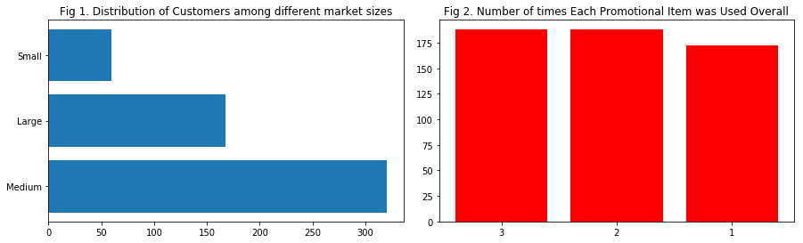

```python
# Marketing Campaign Data
plt.figure(figsize=(15,10))
plt.subplots_adjust(left=None, bottom=None, right=None, top=None, wspace=0.1, hspace=0.4)

#-------------------------------------------
plt.subplot(2,2,1)
market_size_b = marketing_camp_df.MarketSize.value_counts()
plt.barh(market_size_b.index, market_size_b)
plt.title('Fig 1. Distribution of Customers among different market sizes')

#-------------------------------------------
plt.subplot(2,2,2)
promotion_id_b = marketing_camp_df.Promotion.value_counts()
plt.bar([str(x) for x in promotion_id_b.index], promotion_id_b, color='r')
plt.title('Fig 2. Number of times Each Promotional Item was Used Overall');
#-------------------------------------------
```

### Exploring Interesting Relationships Within the Dataset

The visual analysis below yields the following interesting observations:

- **Figure 1**: Although you can clearly see a winner in terms of which group of marketing promotional assets secure the most sales revenue, we also observe that the overall variance between revenue secured is minimal. Furthermore, it would be inappropriate to attribute the sales revenue entirely on the promotional materials used as there exist several other variables that could influence revenue.
- **Figure 2**: We observe here no significant relationship between the time when a promotional asset is used in a marketing asset vs the group of the promotional asset. For example: promotion group 1 performs well in the later weeks of application whereas promotion groups 2 & 3 perform perform indifferently over the 4 weeks they were deployed.
- **Figure 3**: We observe another pattern of indifference here wherein we cannot see clearly if a certain combination of promotion group and market size worked *significantly* better than any other group.
- **Figure 4**: Marketing campaigns have clearly brought in more revenue for younger stores in larger markets. Perhaps the reasoning behind this phenomenon is that relatively newer, successful stores in more larger markets have the opportunity to convert a larger target audience and therefore experience quicker results. We observe that medium markets prove more lucrative towards older, more established stores. Small markets, however, have polarized results thereby indicating a "hit or miss" phenomenon with marketing campaigns.

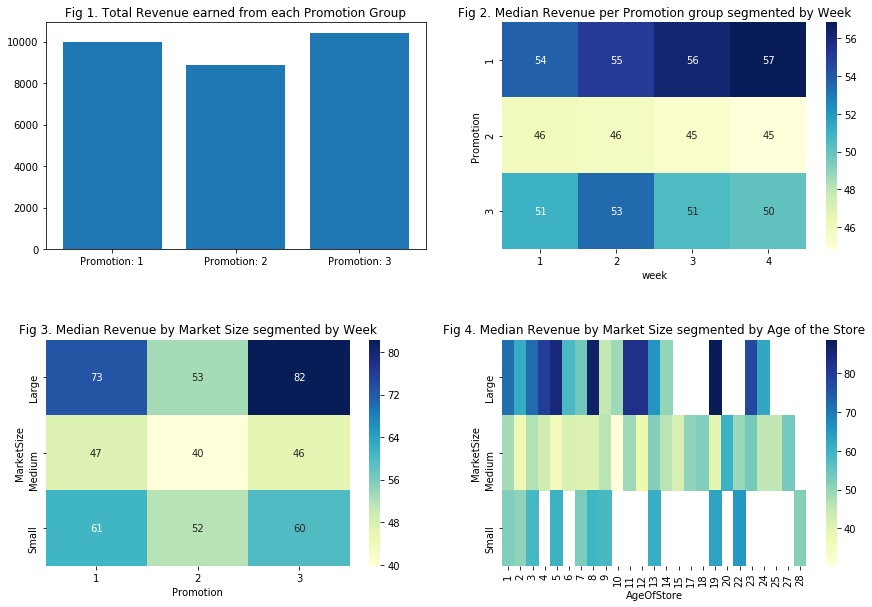

```python
# Marketing Campaign Data
plt.figure(figsize=(15,10))
plt.subplots_adjust(left=None, bottom=None, right=None, top=None, wspace=0.2, hspace=0.4)

#-------------------------------------------
plt.subplot(2,2,1)

zuz= marketing_camp_df.groupby(['Promotion'])['SalesInThousands'].sum()
plt.bar(['Promotion: {}'.format(x) for x in zuz.index],zuz)
plt.title('Fig 1. Total Revenue earned from each Promotion Group')

#-------------------------------------------
plt.subplot(2,2,2)
plt.title('Fig 2. Median Revenue per Promotion group segmented by Week')
sns.heatmap(marketing_camp_df.groupby(['Promotion', 'week'])['SalesInThousands'].median().unstack()
           , annot=True,fmt='1.0f', cmap="YlGnBu")

#-------------------------------------------
plt.subplot(2,2,3)
plt.title('Fig 3. Median Revenue by Market Size segmented by Week')
sns.heatmap(marketing_camp_df.groupby(['MarketSize', 'Promotion'])['SalesInThousands'].median().unstack()
           , annot=True,fmt='1.0f', cmap="YlGnBu")

#-------------------------------------------
plt.subplot(2,2,4)
plt.title('Fig 4. Median Revenue by Market Size segmented by Age of the Store')
sns.heatmap(marketing_camp_df.groupby(['MarketSize', 'AgeOfStore'])['SalesInThousands'].median().unstack()
           , cmap="YlGnBu");
```

### B) Forming a Hypothesis

As I have alluded to earlier, marketing campaigns aim to serve a variety of purposes. The dataset here comprises sales data, therefore I will assume that the marketing campaign data in the dataset pertains to activity directly related with sales. For instance, urging a potential customer to make a purchase by leveraging the campaign promotion offer. It could be a discount, free shipping or any other form of marketing asset.

I would like to continue my analysis by exploring the following hypothesis: **A combination of related independent variables will assist in developing predictive models to predict the Sales Revenue from a marketing campaign.**

**Note: However, I will convert this problem into a classification problem.** The idea here is to bucket the numerical dependent variable `SalesInThousands` into different groups. Following which I will look to fitting a predictive model that will try and accurately predict if a certain marketing campaign will yield revenue that will fall in one of custom made categories. The following illustration will clarify this concept:

- Given that the `SalesInThousands` data ranges from $\$$17.3 to $\$$99.6 thousand, I will divide the data as follows:
  - Sales between $\$$0 and $\$$40 thousand falls in category 1
  - Sales between $\$$40 and $\$$45 thousand falls in category 2
  - Sales between $\$$45 and $\$$50 thousand falls in category 3
    ... and so on

    Note here that each category is not equally spaced. This is because there would be a class imbalance in our dataset. For your reference: a class imbalance is when the number of a class of certain category is far less than the total number of another class of category or categories. Therefore I have categorized the `SalesInThousands` such that no particular category is disproportionately represented.

```python
# Figure out the boundaries for each category
bins = [0,40,45,50,55,60,80,100]
marketing_camp_df['binned_sales'] = pd.cut(marketing_camp_df['SalesInThousands'], bins)
```

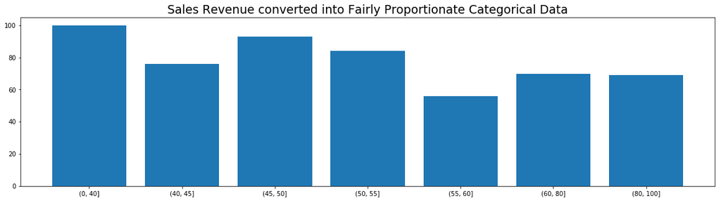

```python
plt.figure(figsize=(20,5))
aaaa = pd.DataFrame(marketing_camp_df.binned_sales.value_counts())
aaaa= aaaa.sort_index()
aaaa['cats'] = aaaa.index
plt.bar(aaaa.cats.astype(str),aaaa.binned_sales)
plt.title('Sales Revenue converted into Fairly Proportionate Categorical Data', size=19);
```

### C) Feature Selection Using Statistical Techniques

In order to find the "combination of variables" that will allow me to predict the categorized `SalesInThousands`, I will need to determine which variables or features will contribute the most to the prediction variable. Unlike case 1, however, I will employ the use of a different statistical test:

- **Chi - Square Tests**: The chi-square test tests the independence of two variables. Similar to how a correlation coefficient tests independence between two numerical variables, Chi-Square tests perform similar tests of independence but only between categorical or nominal variables. The Null hypothesis in Chi-Square tests is that the variables in comparison are independent and therefore have no association. The alternate hypothesis is that they are not independent and therefore have some association between them. Depending on the use case, we can decide when it is good when variables are independent vs when they are not.

#### **a)**: Chi-Square Tests to determine independence between categorical features and categorical target variable

```python
# Get all combinations
categorical_vars_combs_2_mc =  pd.DataFrame([('binned_sales',x) for x in ['MarketSize', 'Promotion', 'week']]
                                         , columns = ['column_1', 'column_2'])
```

```python
categorical_vars_combs_2_mc['p_value_chi_sq']=  categorical_vars_combs_2_mc.apply(chi_sq_test,1, data=marketing_camp_df)
```

```python
print('P-value scores from conducting chi-square tests on all combinations of categorical features')
print('----------------------------')
categorical_vars_combs_2_mc
```

```
P-value scores from conducting chi-square tests on all combinations of categorical features
----------------------------
```

|  | column_1 | column_2 | p_value_chi_sq |
| --- | --- | --- | --- |
| 0 | binned_sales | MarketSize | 2.068545e-67 |
| 1 | binned_sales | Promotion | 9.485010e-10 |
| 2 | binned_sales | week | 9.290525e-01 |

### D) Feature Engineering

Feature engineering is almost always needed in order to convert dataset into an appropriate format to fit the predictive model. Similar to case 1, I will convert the categorical data into one-hot encoded data using the `dummies` feature `Pandas` provides

```python
# X values
X = marketing_camp_df[['MarketSize', 'Promotion', 'week']].astype(str)
X_dummies = pd.get_dummies(X)

# Y values
y = marketing_camp_df.binned_sales
```

```python
print ('One-hot encoded Data ')
print('----------------------------')
X_dummies.head(2)
```

```
One-hot encoded Data
----------------------------
```

|  | MarketSize_Large | MarketSize_Medium | MarketSize_Small | Promotion_1 | Promotion_2 | Promotion_3 | week_1 | week_2 | week_3 | week_4 |
| --- | --- | --- | --- | --- | --- | --- | --- | --- | --- | --- |
| 0 | 0 | 1 | 0 | 0 | 0 | 1 | 1 | 0 | 0 | 0 |
| 1 | 0 | 1 | 0 | 0 | 0 | 1 | 0 | 1 | 0 | 0 |

### E) Training and Testing a Predictive Model

Given that the task at hand here is a classification task, I will employ them use of a multinomial logistic regression model. Although more advanced ML techniques such as Neural Networks may be applied, the small size of the dataset may respond better to simpler techniques.

My approach here will be as follows:

- First, I will perform some hyper-parameter tuning to determine which combination of the percentage of test data size and cross validation yields the best outcome
- Second, I will retrain the model on the "optimal" model parameters and then gauge its effectiveness to predict categorized Sales Revenue

```python
# Combinations of Cross Validation and Test size
cross_val_parameters = range(3,7)
test_size_parameters = [0.05,0.07, 0.09, 0.10, 0.15]

# Combinations DataFrame
cross_test_combinations_df = pd.DataFrame([(x,y) for x in cross_val_parameters for y in test_size_parameters]
                                      , columns = ['column_1', 'column_2'])
```

```python
print('Some of the combinations of Cross Validation Size (column_1) and % of data to allocate as test data (column_2)')
print('----------------------------')
cross_test_combinations_df.head(10)
```

```
Some of the combinations of Cross Validation Size (column_1) and % of data to allocate as test data (column_2)
----------------------------
```

|  | column_1 | column_2 |
| --- | --- | --- |
| 0 | 3 | 0.05 |
| 1 | 3 | 0.07 |
| 2 | 3 | 0.09 |
| 3 | 3 | 0.10 |
| 4 | 3 | 0.15 |
| 5 | 4 | 0.05 |
| 6 | 4 | 0.07 |
| 7 | 4 | 0.09 |
| 8 | 4 | 0.10 |
| 9 | 4 | 0.15 |

```python
def logistic_model(row):
    """
    Performs Logistic Regression Using a combination of hyperparameters
    """
    # Splitting up data into training and testing
    X_train, X_test, y_train, y_test = train_test_split(X_dummies, y.astype(str), test_size=row['column_2'], random_state=21)

    # Training Model
    clf = LogisticRegressionCV(cv= int(row['column_1']) ).fit(X_train, y_train )

    print('Fitting Logistic Regression Model Using Crossvalidation: {}, Test size: {}'.format( row['column_1'],row['column_2']))
    # Testing Model
    return clf.score(X_test,y_test)
```

```python
print('Fitting Logistic Regression Models on Different Combinations of Crossvalidation & Test Sizes')
print('----------------------------')
cross_test_combinations_df['logistic_accuracy_score'] = cross_test_combinations_df.apply(logistic_model,1)
```

```
Fitting Logistic Regression Models on Different Combinations of Crossvalidation & Test Sizes
----------------------------
Fitting Logistic Regression Model Using Crossvalidation: 3.0, Test size: 0.05
Fitting Logistic Regression Model Using Crossvalidation: 3.0, Test size: 0.07
Fitting Logistic Regression Model Using Crossvalidation: 3.0, Test size: 0.09
Fitting Logistic Regression Model Using Crossvalidation: 3.0, Test size: 0.1
Fitting Logistic Regression Model Using Crossvalidation: 3.0, Test size: 0.15
Fitting Logistic Regression Model Using Crossvalidation: 4.0, Test size: 0.05
Fitting Logistic Regression Model Using Crossvalidation: 4.0, Test size: 0.07
Fitting Logistic Regression Model Using Crossvalidation: 4.0, Test size: 0.09
Fitting Logistic Regression Model Using Crossvalidation: 4.0, Test size: 0.1
Fitting Logistic Regression Model Using Crossvalidation: 4.0, Test size: 0.15
Fitting Logistic Regression Model Using Crossvalidation: 5.0, Test size: 0.05
Fitting Logistic Regression Model Using Crossvalidation: 5.0, Test size: 0.07
Fitting Logistic Regression Model Using Crossvalidation: 5.0, Test size: 0.09
Fitting Logistic Regression Model Using Crossvalidation: 5.0, Test size: 0.1
Fitting Logistic Regression Model Using Crossvalidation: 5.0, Test size: 0.15
Fitting Logistic Regression Model Using Crossvalidation: 6.0, Test size: 0.05
Fitting Logistic Regression Model Using Crossvalidation: 6.0, Test size: 0.07
Fitting Logistic Regression Model Using Crossvalidation: 6.0, Test size: 0.09
Fitting Logistic Regression Model Using Crossvalidation: 6.0, Test size: 0.1
Fitting Logistic Regression Model Using Crossvalidation: 6.0, Test size: 0.15
```

```python
cross_test_combinations_df.sort_values('logistic_accuracy_score', ascending=False).head(1)
```

|  | column_1 | column_2 | logistic_accuracy_score |
| --- | --- | --- | --- |
| 11 | 5 | 0.07 | 0.538462 |

#### Refitting the Model

Through the hyper-parameter tuning process conducted above, we observe that a cross-validation value of 5 along with a 7% test size leads to the highest accuracy rate.

```python
# Splitting up data into training and testing
X_train, X_test, y_train, y_test = train_test_split(X_dummies, y.astype(str), test_size=0.07, random_state=21)

# Training Model
clf_final = LogisticRegressionCV(cv= 5).fit(X_train, y_train )
# Accuracy Score
print ('Accuracy score for the classification model is ',round(clf_final.score(X_test,y_test) * 100,2),'%')
```

```
Accuracy score for the classification model is  53.85 %
```

### F) Interpreting Results

A multinomial logistic regression model yields an accuracy score of **54%**, which is not suitable for production level work. Furthermore, using a confusion matrix, we can observe how our model performs reasonably well when it comes to predicting whether marketing campaigns will yield sales revenue between $\$$0 to $\$$40,000 , and between $\$$80 to $\$$100,000. However, all other categories are poorly predicted.

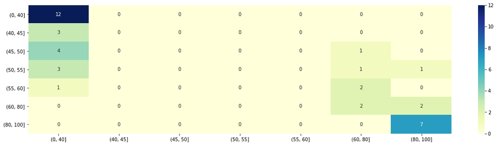

```python
plt.figure(figsize=(20,5))
sns.heatmap(confusion_matrix(y_test, clf_final.predict(X_test), labels=np.unique(marketing_camp_df.binned_sales.astype(str)))
           , cmap="YlGnBu", annot=True, xticklabels=np.unique(marketing_camp_df.binned_sales.astype(str)), yticklabels=np.unique(marketing_camp_df.binned_sales.astype(str)));
```